# Risk Factor Analysis

## Outcome Variable

**Outcome Variable:** ever_stunted

## Predictor Variables

**Intervention Variable:** mage

**Adjustment Set:**

- arm
- meducyrs
- feducyrs
- W_mhtcm
- W_mwtkg
- W_mbmi
- single
- delta_meducyrs
- delta_feducyrs
- delta_W_mhtcm
- delta_W_mwtkg
- delta_W_mbmi
- delta_single

## Stratifying Variables

The analysis was stratified on these variable(s):

- agecat
- studyid
- country

## Data Summary

| agecat | studyid | country | mage | ever_stunted | n_cell | n |
| --- | --- | --- | --- | --- | --- | --- |
| 0-24 months | CMC-V-BCS-2002 | INDIA | [20-30) | 0 | 22 | 373 |
| 0-24 months | CMC-V-BCS-2002 | INDIA | [20-30) | 1 | 274 | 373 |
| 0-24 months | CMC-V-BCS-2002 | INDIA | <20 | 0 | 3 | 373 |
| 0-24 months | CMC-V-BCS-2002 | INDIA | <20 | 1 | 31 | 373 |
| 0-24 months | CMC-V-BCS-2002 | INDIA | >=30 | 0 | 3 | 373 |
| 0-24 months | CMC-V-BCS-2002 | INDIA | >=30 | 1 | 40 | 373 |
| 0-24 months | COHORTS | GUATEMALA | [20-30) | 0 | 151 | 1360 |
| 0-24 months | COHORTS | GUATEMALA | [20-30) | 1 | 510 | 1360 |
| 0-24 months | COHORTS | GUATEMALA | <20 | 0 | 52 | 1360 |
| 0-24 months | COHORTS | GUATEMALA | <20 | 1 | 150 | 1360 |
| 0-24 months | COHORTS | GUATEMALA | >=30 | 0 | 118 | 1360 |
| 0-24 months | COHORTS | GUATEMALA | >=30 | 1 | 379 | 1360 |
| 0-24 months | COHORTS | INDIA | [20-30) | 0 | 2274 | 5313 |
| 0-24 months | COHORTS | INDIA | [20-30) | 1 | 1328 | 5313 |
| 0-24 months | COHORTS | INDIA | <20 | 0 | 248 | 5313 |
| 0-24 months | COHORTS | INDIA | <20 | 1 | 179 | 5313 |
| 0-24 months | COHORTS | INDIA | >=30 | 0 | 731 | 5313 |
| 0-24 months | COHORTS | INDIA | >=30 | 1 | 553 | 5313 |
| 0-24 months | COHORTS | PHILIPPINES | [20-30) | 0 | 607 | 3058 |
| 0-24 months | COHORTS | PHILIPPINES | [20-30) | 1 | 1220 | 3058 |
| 0-24 months | COHORTS | PHILIPPINES | <20 | 0 | 103 | 3058 |
| 0-24 months | COHORTS | PHILIPPINES | <20 | 1 | 275 | 3058 |
| 0-24 months | COHORTS | PHILIPPINES | >=30 | 0 | 249 | 3058 |
| 0-24 months | COHORTS | PHILIPPINES | >=30 | 1 | 604 | 3058 |
| 0-24 months | EE | PAKISTAN | [20-30) | 0 | 20 | 377 |
| 0-24 months | EE | PAKISTAN | [20-30) | 1 | 142 | 377 |
| 0-24 months | EE | PAKISTAN | <20 | 0 | 0 | 377 |
| 0-24 months | EE | PAKISTAN | <20 | 1 | 1 | 377 |
| 0-24 months | EE | PAKISTAN | >=30 | 0 | 21 | 377 |
| 0-24 months | EE | PAKISTAN | >=30 | 1 | 193 | 377 |

[output cut: 450 more lines]

The following strata were considered:

- agecat: 0-24 months, studyid: CMC-V-BCS-2002, country: INDIA
- agecat: 0-24 months, studyid: COHORTS, country: GUATEMALA
- agecat: 0-24 months, studyid: COHORTS, country: INDIA
- agecat: 0-24 months, studyid: COHORTS, country: PHILIPPINES
- agecat: 0-24 months, studyid: EE, country: PAKISTAN
- agecat: 0-24 months, studyid: GMS-Nepal, country: NEPAL
- agecat: 0-24 months, studyid: Guatemala BSC, country: GUATEMALA
- agecat: 0-24 months, studyid: iLiNS-Zinc, country: BURKINA FASO
- agecat: 0-24 months, studyid: IRC, country: INDIA
- agecat: 0-24 months, studyid: JiVitA-3, country: BANGLADESH
- agecat: 0-24 months, studyid: Keneba, country: GAMBIA
- agecat: 0-24 months, studyid: LCNI-5, country: MALAWI
- agecat: 0-24 months, studyid: MAL-ED, country: BANGLADESH
- agecat: 0-24 months, studyid: MAL-ED, country: BRAZIL
- agecat: 0-24 months, studyid: MAL-ED, country: INDIA
- agecat: 0-24 months, studyid: MAL-ED, country: NEPAL
- agecat: 0-24 months, studyid: MAL-ED, country: PERU
- agecat: 0-24 months, studyid: MAL-ED, country: SOUTH AFRICA
- agecat: 0-24 months, studyid: MAL-ED, country: TANZANIA, UNITED REPUBLIC OF
- agecat: 0-24 months, studyid: NIH-Birth, country: BANGLADESH
- agecat: 0-24 months, studyid: NIH-Crypto, country: BANGLADESH
- agecat: 0-24 months, studyid: PROBIT, country: BELARUS
- agecat: 0-24 months, studyid: PROVIDE, country: BANGLADESH
- agecat: 0-24 months, studyid: SAS-CompFeed, country: INDIA
- agecat: 0-24 months, studyid: SAS-FoodSuppl, country: INDIA
- agecat: 0-24 months, studyid: TanzaniaChild2, country: TANZANIA, UNITED REPUBLIC OF
- agecat: 0-24 months, studyid: ZVITAMBO, country: ZIMBABWE
- agecat: 0-6 months, studyid: CMC-V-BCS-2002, country: INDIA
- agecat: 0-6 months, studyid: COHORTS, country: GUATEMALA
- agecat: 0-6 months, studyid: COHORTS, country: INDIA
- agecat: 0-6 months, studyid: COHORTS, country: PHILIPPINES
- agecat: 0-6 months, studyid: EE, country: PAKISTAN
- agecat: 0-6 months, studyid: GMS-Nepal, country: NEPAL
- agecat: 0-6 months, studyid: Guatemala BSC, country: GUATEMALA
- agecat: 0-6 months, studyid: IRC, country: INDIA
- agecat: 0-6 months, studyid: JiVitA-3, country: BANGLADESH
- agecat: 0-6 months, studyid: Keneba, country: GAMBIA
- agecat: 0-6 months, studyid: LCNI-5, country: MALAWI
- agecat: 0-6 months, studyid: MAL-ED, country: BANGLADESH
- agecat: 0-6 months, studyid: MAL-ED, country: BRAZIL
- agecat: 0-6 months, studyid: MAL-ED, country: INDIA
- agecat: 0-6 months, studyid: MAL-ED, country: NEPAL
- agecat: 0-6 months, studyid: MAL-ED, country: PERU
- agecat: 0-6 months, studyid: MAL-ED, country: SOUTH AFRICA
- agecat: 0-6 months, studyid: MAL-ED, country: TANZANIA, UNITED REPUBLIC OF
- agecat: 0-6 months, studyid: NIH-Birth, country: BANGLADESH
- agecat: 0-6 months, studyid: NIH-Crypto, country: BANGLADESH
- agecat: 0-6 months, studyid: PROBIT, country: BELARUS
- agecat: 0-6 months, studyid: PROVIDE, country: BANGLADESH
- agecat: 0-6 months, studyid: SAS-CompFeed, country: INDIA
- agecat: 0-6 months, studyid: SAS-FoodSuppl, country: INDIA
- agecat: 0-6 months, studyid: TanzaniaChild2, country: TANZANIA, UNITED REPUBLIC OF
- agecat: 0-6 months, studyid: ZVITAMBO, country: ZIMBABWE
- agecat: 6-24 months, studyid: CMC-V-BCS-2002, country: INDIA
- agecat: 6-24 months, studyid: COHORTS, country: GUATEMALA
- agecat: 6-24 months, studyid: COHORTS, country: INDIA
- agecat: 6-24 months, studyid: COHORTS, country: PHILIPPINES
- agecat: 6-24 months, studyid: EE, country: PAKISTAN
- agecat: 6-24 months, studyid: GMS-Nepal, country: NEPAL
- agecat: 6-24 months, studyid: Guatemala BSC, country: GUATEMALA
- agecat: 6-24 months, studyid: iLiNS-Zinc, country: BURKINA FASO
- agecat: 6-24 months, studyid: IRC, country: INDIA
- agecat: 6-24 months, studyid: JiVitA-3, country: BANGLADESH
- agecat: 6-24 months, studyid: Keneba, country: GAMBIA
- agecat: 6-24 months, studyid: LCNI-5, country: MALAWI
- agecat: 6-24 months, studyid: MAL-ED, country: BANGLADESH
- agecat: 6-24 months, studyid: MAL-ED, country: BRAZIL
- agecat: 6-24 months, studyid: MAL-ED, country: INDIA
- agecat: 6-24 months, studyid: MAL-ED, country: NEPAL
- agecat: 6-24 months, studyid: MAL-ED, country: PERU
- agecat: 6-24 months, studyid: MAL-ED, country: SOUTH AFRICA
- agecat: 6-24 months, studyid: MAL-ED, country: TANZANIA, UNITED REPUBLIC OF
- agecat: 6-24 months, studyid: NIH-Birth, country: BANGLADESH
- agecat: 6-24 months, studyid: NIH-Crypto, country: BANGLADESH
- agecat: 6-24 months, studyid: PROBIT, country: BELARUS
- agecat: 6-24 months, studyid: PROVIDE, country: BANGLADESH
- agecat: 6-24 months, studyid: SAS-CompFeed, country: INDIA
- agecat: 6-24 months, studyid: SAS-FoodSuppl, country: INDIA
- agecat: 6-24 months, studyid: TanzaniaChild2, country: TANZANIA, UNITED REPUBLIC OF
- agecat: 6-24 months, studyid: ZVITAMBO, country: ZIMBABWE

### Dropped Strata

Some strata were dropped due to rare outcomes:

- agecat: 0-24 months, studyid: CMC-V-BCS-2002, country: INDIA
- agecat: 0-24 months, studyid: EE, country: PAKISTAN
- agecat: 0-24 months, studyid: MAL-ED, country: NEPAL
- agecat: 0-24 months, studyid: MAL-ED, country: TANZANIA, UNITED REPUBLIC OF
- agecat: 0-6 months, studyid: EE, country: PAKISTAN
- agecat: 0-6 months, studyid: MAL-ED, country: INDIA
- agecat: 0-6 months, studyid: MAL-ED, country: NEPAL
- agecat: 6-24 months, studyid: CMC-V-BCS-2002, country: INDIA
- agecat: 6-24 months, studyid: EE, country: PAKISTAN
- agecat: 6-24 months, studyid: IRC, country: INDIA
- agecat: 6-24 months, studyid: MAL-ED, country: BRAZIL
- agecat: 6-24 months, studyid: MAL-ED, country: NEPAL
- agecat: 6-24 months, studyid: MAL-ED, country: TANZANIA, UNITED REPUBLIC OF

## Methods Detail

We're interested in the causal parameters $E[Y_a]$ for all values of $a \in \mathcal{A}$. These parameters represent the mean outcome if, possibly contrary to fact, we intervened to set all units to have $A=a$. Under the randomization and positivity assumptions, these are identified by the statistical parameters $\psi_a=E_W[E_{Y|A,W}(Y|A=a,W)]$. In addition, we're interested in the mean of $Y$, $E[Y]$ under no intervention (the observed mean). We will estimate these parameters by using SuperLearner to fit the relevant likelihood factors -- $E_{Y|A,W}(Y|A=a,W)$ and $p(A=a|W)$, and then updating our likelihood fit using a joint TMLE.

For unadjusted analyses ($W=\{\}$), initial likelihoods were estimated using Lrnr_glm to estimate the simple $E(Y|A)$ and Lrnr_mean to estimate $p(A)$. For adjusted analyses, a small library containing Lrnr_glmnet, Lrnr_xgboost, and Lrnr_mean was used.

Having estimated these parameters, we will then use the delta method to estimate relative risks and attributable risks relative to a prespecified baseline level of $A$.

# Results Detail

## Results Plots

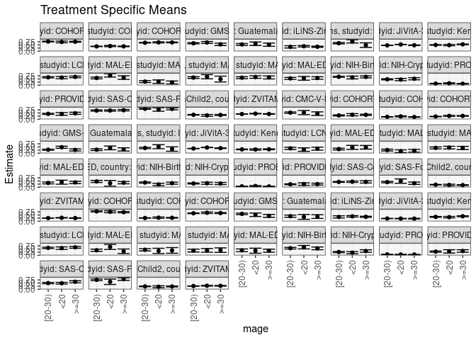

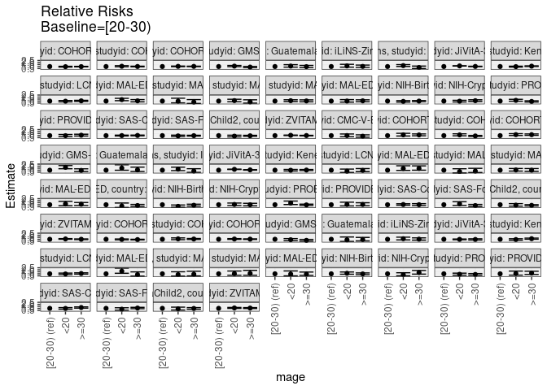

[figure not shown]

[figure not shown]

## Results Table

### Parameter: TSM

| agecat | studyid | country | intervention_level | baseline_level | estimate | ci_lower | ci_upper |
| --- | --- | --- | --- | --- | --- | --- | --- |
| 0-24 months | COHORTS | GUATEMALA | [20-30) | NA | 0.7714213 | 0.7382868 | 0.8045558 |
| 0-24 months | COHORTS | GUATEMALA | <20 | NA | 0.7408399 | 0.6719787 | 0.8097010 |
| 0-24 months | COHORTS | GUATEMALA | >=30 | NA | 0.7551390 | 0.7165948 | 0.7936833 |
| 0-24 months | COHORTS | INDIA | [20-30) | NA | 0.3833333 | 0.3673455 | 0.3993211 |
| 0-24 months | COHORTS | INDIA | <20 | NA | 0.4090420 | 0.3623338 | 0.4557501 |
| 0-24 months | COHORTS | INDIA | >=30 | NA | 0.3870306 | 0.3602765 | 0.4137847 |
| 0-24 months | COHORTS | PHILIPPINES | [20-30) | NA | 0.6762925 | 0.6550064 | 0.6975787 |
| 0-24 months | COHORTS | PHILIPPINES | <20 | NA | 0.7070255 | 0.6617841 | 0.7522669 |
| 0-24 months | COHORTS | PHILIPPINES | >=30 | NA | 0.7010016 | 0.6717018 | 0.7303015 |
| 0-24 months | GMS-Nepal | NEPAL | [20-30) | NA | 0.6318501 | 0.5868224 | 0.6768777 |
| 0-24 months | GMS-Nepal | NEPAL | <20 | NA | 0.6967205 | 0.6195376 | 0.7739033 |
| 0-24 months | GMS-Nepal | NEPAL | >=30 | NA | 0.5452856 | 0.4516278 | 0.6389434 |
| 0-24 months | Guatemala BSC | GUATEMALA | [20-30) | NA | 0.5371636 | 0.4634705 | 0.6108567 |
| 0-24 months | Guatemala BSC | GUATEMALA | <20 | NA | 0.5977394 | 0.4565848 | 0.7388940 |
| 0-24 months | Guatemala BSC | GUATEMALA | >=30 | NA | 0.5187810 | 0.3900676 | 0.6474943 |
| 0-24 months | iLiNS-Zinc | BURKINA FASO | [20-30) | NA | 0.3455169 | 0.2556098 | 0.4354240 |
| 0-24 months | iLiNS-Zinc | BURKINA FASO | <20 | NA | 0.3960692 | 0.3377722 | 0.4543661 |
| 0-24 months | iLiNS-Zinc | BURKINA FASO | >=30 | NA | 0.3558881 | 0.3121784 | 0.3995979 |
| 0-24 months | IRC | INDIA | [20-30) | NA | 0.6395349 | 0.5887350 | 0.6903348 |
| 0-24 months | IRC | INDIA | <20 | NA | 0.7837838 | 0.6509771 | 0.9165904 |
| 0-24 months | IRC | INDIA | >=30 | NA | 0.4827586 | 0.3006666 | 0.6648507 |
| 0-24 months | JiVitA-3 | BANGLADESH | [20-30) | NA | 0.4643326 | 0.4536813 | 0.4749838 |
| 0-24 months | JiVitA-3 | BANGLADESH | <20 | NA | 0.5347292 | 0.5238865 | 0.5455719 |
| 0-24 months | JiVitA-3 | BANGLADESH | >=30 | NA | 0.4747428 | 0.4507903 | 0.4986953 |
| 0-24 months | Keneba | GAMBIA | [20-30) | NA | 0.5001650 | 0.4744680 | 0.5258621 |
| 0-24 months | Keneba | GAMBIA | <20 | NA | 0.4862801 | 0.4347742 | 0.5377860 |
| 0-24 months | Keneba | GAMBIA | >=30 | NA | 0.5459476 | 0.5156495 | 0.5762457 |
| 0-24 months | LCNI-5 | MALAWI | [20-30) | NA | 0.6293118 | 0.5802642 | 0.6783593 |
| 0-24 months | LCNI-5 | MALAWI | <20 | NA | 0.6073589 | 0.5152300 | 0.6994878 |
| 0-24 months | LCNI-5 | MALAWI | >=30 | NA | 0.6647429 | 0.5995804 | 0.7299055 |

[output cut: 171 more lines]

### Parameter: E(Y)

| agecat | studyid | country | intervention_level | baseline_level | estimate | ci_lower | ci_upper |
| --- | --- | --- | --- | --- | --- | --- | --- |
| 0-24 months | COHORTS | GUATEMALA | NA | NA | 0.7639706 | 0.7413939 | 0.7865473 |
| 0-24 months | COHORTS | INDIA | NA | NA | 0.3877282 | 0.3746257 | 0.4008307 |
| 0-24 months | COHORTS | PHILIPPINES | NA | NA | 0.6863963 | 0.6699496 | 0.7028430 |
| 0-24 months | GMS-Nepal | NEPAL | NA | NA | 0.6389685 | 0.6033115 | 0.6746254 |
| 0-24 months | Guatemala BSC | GUATEMALA | NA | NA | 0.5551601 | 0.4969525 | 0.6133678 |
| 0-24 months | iLiNS-Zinc | BURKINA FASO | NA | NA | 0.3561989 | 0.3061990 | 0.4061987 |
| 0-24 months | IRC | INDIA | NA | NA | 0.6414634 | 0.5949863 | 0.6879405 |
| 0-24 months | JiVitA-3 | BANGLADESH | NA | NA | 0.4952969 | 0.4874720 | 0.5031218 |
| 0-24 months | Keneba | GAMBIA | NA | NA | 0.5183631 | 0.5000444 | 0.5366817 |
| 0-24 months | LCNI-5 | MALAWI | NA | NA | 0.6373134 | 0.6008819 | 0.6737450 |
| 0-24 months | MAL-ED | BANGLADESH | NA | NA | 0.6113208 | 0.5525209 | 0.6701206 |
| 0-24 months | MAL-ED | BRAZIL | NA | NA | 0.2703863 | 0.2132328 | 0.3275398 |
| 0-24 months | MAL-ED | INDIA | NA | NA | 0.6024096 | 0.5415000 | 0.6633193 |
| 0-24 months | MAL-ED | PERU | NA | NA | 0.6204620 | 0.5657315 | 0.6751926 |
| 0-24 months | MAL-ED | SOUTH AFRICA | NA | NA | 0.5605096 | 0.5055248 | 0.6154943 |
| 0-24 months | NIH-Birth | BANGLADESH | NA | NA | 0.6634769 | 0.6264616 | 0.7004922 |
| 0-24 months | NIH-Crypto | BANGLADESH | NA | NA | 0.4775726 | 0.4419904 | 0.5131548 |
| 0-24 months | PROBIT | BELARUS | NA | NA | 0.1274191 | 0.1115552 | 0.1432829 |
| 0-24 months | PROVIDE | BANGLADESH | NA | NA | 0.4357143 | 0.3989556 | 0.4724730 |
| 0-24 months | SAS-CompFeed | INDIA | NA | NA | 0.6914547 | 0.6510509 | 0.7318584 |
| 0-24 months | SAS-FoodSuppl | INDIA | NA | NA | 0.8277512 | 0.7915095 | 0.8639929 |
| 0-24 months | TanzaniaChild2 | TANZANIA, UNITED REPUBLIC OF | NA | NA | 0.3459596 | 0.3268289 | 0.3650903 |
| 0-24 months | ZVITAMBO | ZIMBABWE | NA | NA | 0.4172011 | 0.4090427 | 0.4253595 |
| 0-6 months | CMC-V-BCS-2002 | INDIA | NA | NA | 0.5108696 | 0.4597270 | 0.5620121 |
| 0-6 months | COHORTS | GUATEMALA | NA | NA | 0.3253896 | 0.2975756 | 0.3532035 |
| 0-6 months | COHORTS | INDIA | NA | NA | 0.1902629 | 0.1795262 | 0.2009996 |
| 0-6 months | COHORTS | PHILIPPINES | NA | NA | 0.2390451 | 0.2239262 | 0.2541640 |
| 0-6 months | GMS-Nepal | NEPAL | NA | NA | 0.3180516 | 0.2834770 | 0.3526261 |
| 0-6 months | Guatemala BSC | GUATEMALA | NA | NA | 0.3181818 | 0.2618904 | 0.3744732 |
| 0-6 months | IRC | INDIA | NA | NA | 0.4243902 | 0.3764905 | 0.4722900 |
| 0-6 months | JiVitA-3 | BANGLADESH | NA | NA | 0.4129650 | 0.4055288 | 0.4204012 |
| 0-6 months | Keneba | GAMBIA | NA | NA | 0.3127302 | 0.2943427 | 0.3311178 |
| 0-6 months | LCNI-5 | MALAWI | NA | NA | 0.3545455 | 0.2911884 | 0.4179025 |
| 0-6 months | MAL-ED | BANGLADESH | NA | NA | 0.3584906 | 0.3006428 | 0.4163383 |
| 0-6 months | MAL-ED | BRAZIL | NA | NA | 0.2231760 | 0.1695976 | 0.2767543 |
| 0-6 months | MAL-ED | PERU | NA | NA | 0.4257426 | 0.3699763 | 0.4815088 |
| 0-6 months | MAL-ED | SOUTH AFRICA | NA | NA | 0.3694268 | 0.3159570 | 0.4228965 |
| 0-6 months | MAL-ED | TANZANIA, UNITED REPUBLIC OF | NA | NA | 0.4160305 | 0.3562327 | 0.4758284 |
| 0-6 months | NIH-Birth | BANGLADESH | NA | NA | 0.3476874 | 0.3103810 | 0.3849938 |
| 0-6 months | NIH-Crypto | BANGLADESH | NA | NA | 0.3021108 | 0.2694011 | 0.3348205 |
| 0-6 months | PROBIT | BELARUS | NA | NA | 0.0686124 | 0.0577768 | 0.0794479 |
| 0-6 months | PROVIDE | BANGLADESH | NA | NA | 0.2400000 | 0.2083392 | 0.2716608 |
| 0-6 months | SAS-CompFeed | INDIA | NA | NA | 0.4254902 | 0.3977202 | 0.4532601 |
| 0-6 months | SAS-FoodSuppl | INDIA | NA | NA | 0.3894231 | 0.3425088 | 0.4363374 |
| 0-6 months | TanzaniaChild2 | TANZANIA, UNITED REPUBLIC OF | NA | NA | 0.1944444 | 0.1785274 | 0.2103615 |
| 0-6 months | ZVITAMBO | ZIMBABWE | NA | NA | 0.2587572 | 0.2515068 | 0.2660076 |
| 6-24 months | COHORTS | GUATEMALA | NA | NA | 0.7642458 | 0.7364214 | 0.7920702 |
| 6-24 months | COHORTS | INDIA | NA | NA | 0.2666174 | 0.2530174 | 0.2802175 |
| 6-24 months | COHORTS | PHILIPPINES | NA | NA | 0.6449788 | 0.6246093 | 0.6653483 |
| 6-24 months | GMS-Nepal | NEPAL | NA | NA | 0.5642317 | 0.5153938 | 0.6130696 |
| 6-24 months | Guatemala BSC | GUATEMALA | NA | NA | 0.3913043 | 0.3205945 | 0.4620142 |
| 6-24 months | iLiNS-Zinc | BURKINA FASO | NA | NA | 0.3561989 | 0.3061990 | 0.4061987 |
| 6-24 months | JiVitA-3 | BANGLADESH | NA | NA | 0.2162471 | 0.2068695 | 0.2256248 |
| 6-24 months | Keneba | GAMBIA | NA | NA | 0.3640974 | 0.3428547 | 0.3853400 |
| 6-24 months | LCNI-5 | MALAWI | NA | NA | 0.6006885 | 0.5608305 | 0.6405464 |
| 6-24 months | MAL-ED | BANGLADESH | NA | NA | 0.4240506 | 0.3467471 | 0.5013542 |
| 6-24 months | MAL-ED | INDIA | NA | NA | 0.4220779 | 0.3438191 | 0.5003367 |
| 6-24 months | MAL-ED | PERU | NA | NA | 0.3959732 | 0.3171819 | 0.4747644 |
| 6-24 months | MAL-ED | SOUTH AFRICA | NA | NA | 0.3797468 | 0.3038314 | 0.4556622 |
| 6-24 months | NIH-Birth | BANGLADESH | NA | NA | 0.5739130 | 0.5216565 | 0.6261696 |
| 6-24 months | NIH-Crypto | BANGLADESH | NA | NA | 0.2628458 | 0.2244546 | 0.3012371 |
| 6-24 months | PROBIT | BELARUS | NA | NA | 0.0642659 | 0.0526827 | 0.0758490 |
| 6-24 months | PROVIDE | BANGLADESH | NA | NA | 0.3004386 | 0.2583143 | 0.3425629 |
| 6-24 months | SAS-CompFeed | INDIA | NA | NA | 0.5030750 | 0.4588491 | 0.5473009 |
| 6-24 months | SAS-FoodSuppl | INDIA | NA | NA | 0.7572016 | 0.7031798 | 0.8112234 |
| 6-24 months | TanzaniaChild2 | TANZANIA, UNITED REPUBLIC OF | NA | NA | 0.2262728 | 0.2057063 | 0.2468392 |
| 6-24 months | ZVITAMBO | ZIMBABWE | NA | NA | 0.2628598 | 0.2534882 | 0.2722315 |

### Parameter: RR

| agecat | studyid | country | intervention_level | baseline_level | estimate | ci_lower | ci_upper |
| --- | --- | --- | --- | --- | --- | --- | --- |
| 0-24 months | COHORTS | GUATEMALA | [20-30) | [20-30) | 1.0000000 | 1.0000000 | 1.0000000 |
| 0-24 months | COHORTS | GUATEMALA | <20 | [20-30) | 0.9603570 | 0.8672420 | 1.0634697 |
| 0-24 months | COHORTS | GUATEMALA | >=30 | [20-30) | 0.9788932 | 0.9164159 | 1.0456299 |
| 0-24 months | COHORTS | INDIA | [20-30) | [20-30) | 1.0000000 | 1.0000000 | 1.0000000 |
| 0-24 months | COHORTS | INDIA | <20 | [20-30) | 1.0670662 | 0.9454598 | 1.2043138 |
| 0-24 months | COHORTS | INDIA | >=30 | [20-30) | 1.0096451 | 0.9322109 | 1.0935114 |
| 0-24 months | COHORTS | PHILIPPINES | [20-30) | [20-30) | 1.0000000 | 1.0000000 | 1.0000000 |
| 0-24 months | COHORTS | PHILIPPINES | <20 | [20-30) | 1.0454432 | 0.9742043 | 1.1218916 |
| 0-24 months | COHORTS | PHILIPPINES | >=30 | [20-30) | 1.0365361 | 0.9847621 | 1.0910321 |
| 0-24 months | GMS-Nepal | NEPAL | [20-30) | [20-30) | 1.0000000 | 1.0000000 | 1.0000000 |
| 0-24 months | GMS-Nepal | NEPAL | <20 | [20-30) | 1.1026674 | 0.9666843 | 1.2577792 |
| 0-24 months | GMS-Nepal | NEPAL | >=30 | [20-30) | 0.8629984 | 0.7171428 | 1.0385188 |
| 0-24 months | Guatemala BSC | GUATEMALA | [20-30) | [20-30) | 1.0000000 | 1.0000000 | 1.0000000 |
| 0-24 months | Guatemala BSC | GUATEMALA | <20 | [20-30) | 1.1127698 | 0.8472031 | 1.4615819 |
| 0-24 months | Guatemala BSC | GUATEMALA | >=30 | [20-30) | 0.9657784 | 0.7279228 | 1.2813555 |
| 0-24 months | iLiNS-Zinc | BURKINA FASO | [20-30) | [20-30) | 1.0000000 | 1.0000000 | 1.0000000 |
| 0-24 months | iLiNS-Zinc | BURKINA FASO | <20 | [20-30) | 1.1463091 | 0.8472462 | 1.5509360 |
| 0-24 months | iLiNS-Zinc | BURKINA FASO | >=30 | [20-30) | 1.0300165 | 0.7803040 | 1.3596420 |
| 0-24 months | IRC | INDIA | [20-30) | [20-30) | 1.0000000 | 1.0000000 | 1.0000000 |
| 0-24 months | IRC | INDIA | <20 | [20-30) | 1.2255528 | 1.0163873 | 1.4777631 |
| 0-24 months | IRC | INDIA | >=30 | [20-30) | 0.7548589 | 0.5134061 | 1.1098662 |
| 0-24 months | JiVitA-3 | BANGLADESH | [20-30) | [20-30) | 1.0000000 | 1.0000000 | 1.0000000 |
| 0-24 months | JiVitA-3 | BANGLADESH | <20 | [20-30) | 1.1516082 | 1.1204042 | 1.1836814 |
| 0-24 months | JiVitA-3 | BANGLADESH | >=30 | [20-30) | 1.0224198 | 0.9692710 | 1.0784829 |
| 0-24 months | Keneba | GAMBIA | [20-30) | [20-30) | 1.0000000 | 1.0000000 | 1.0000000 |
| 0-24 months | Keneba | GAMBIA | <20 | [20-30) | 0.9722392 | 0.8647710 | 1.0930629 |
| 0-24 months | Keneba | GAMBIA | >=30 | [20-30) | 1.0915350 | 1.0132156 | 1.1759083 |
| 0-24 months | LCNI-5 | MALAWI | [20-30) | [20-30) | 1.0000000 | 1.0000000 | 1.0000000 |
| 0-24 months | LCNI-5 | MALAWI | <20 | [20-30) | 0.9651161 | 0.8144624 | 1.1436367 |
| 0-24 months | LCNI-5 | MALAWI | >=30 | [20-30) | 1.0563015 | 0.9332186 | 1.1956179 |

[output cut: 171 more lines]

### Parameter: PAR

| agecat | studyid | country | intervention_level | baseline_level | estimate | ci_lower | ci_upper |
| --- | --- | --- | --- | --- | --- | --- | --- |
| 0-24 months | COHORTS | GUATEMALA | [20-30) | NA | -0.0074507 | -0.0319513 | 0.0170499 |
| 0-24 months | COHORTS | INDIA | [20-30) | NA | 0.0043949 | -0.0048133 | 0.0136031 |
| 0-24 months | COHORTS | PHILIPPINES | [20-30) | NA | 0.0101038 | -0.0026764 | 0.0228840 |
| 0-24 months | GMS-Nepal | NEPAL | [20-30) | NA | 0.0071184 | -0.0196429 | 0.0338797 |
| 0-24 months | Guatemala BSC | GUATEMALA | [20-30) | NA | 0.0179966 | -0.0272756 | 0.0632687 |
| 0-24 months | iLiNS-Zinc | BURKINA FASO | [20-30) | NA | 0.0106820 | -0.0364629 | 0.0578268 |
| 0-24 months | IRC | INDIA | [20-30) | NA | 0.0019285 | -0.0183280 | 0.0221851 |
| 0-24 months | JiVitA-3 | BANGLADESH | [20-30) | NA | 0.0309643 | 0.0239241 | 0.0380046 |
| 0-24 months | Keneba | GAMBIA | [20-30) | NA | 0.0181980 | 0.0003182 | 0.0360779 |
| 0-24 months | LCNI-5 | MALAWI | [20-30) | NA | 0.0080017 | -0.0246378 | 0.0406412 |
| 0-24 months | MAL-ED | BANGLADESH | [20-30) | NA | 0.0343977 | -0.0046598 | 0.0734552 |
| 0-24 months | MAL-ED | BRAZIL | [20-30) | NA | -0.0189863 | -0.0681175 | 0.0301449 |
| 0-24 months | MAL-ED | INDIA | [20-30) | NA | -0.0065474 | -0.0392784 | 0.0261835 |
| 0-24 months | MAL-ED | PERU | [20-30) | NA | 0.0209392 | -0.0330252 | 0.0749037 |
| 0-24 months | MAL-ED | SOUTH AFRICA | [20-30) | NA | 0.0163392 | -0.0368281 | 0.0695064 |
| 0-24 months | NIH-Birth | BANGLADESH | [20-30) | NA | -0.0081386 | -0.0333138 | 0.0170366 |
| 0-24 months | NIH-Crypto | BANGLADESH | [20-30) | NA | 0.0071509 | -0.0185067 | 0.0328085 |
| 0-24 months | PROBIT | BELARUS | [20-30) | NA | -0.0009515 | -0.0050411 | 0.0031380 |
| 0-24 months | PROVIDE | BANGLADESH | [20-30) | NA | 0.0063921 | -0.0163416 | 0.0291258 |
| 0-24 months | SAS-CompFeed | INDIA | [20-30) | NA | 0.0021008 | -0.0117798 | 0.0159813 |
| 0-24 months | SAS-FoodSuppl | INDIA | [20-30) | NA | -0.0067316 | -0.0312810 | 0.0178179 |
| 0-24 months | TanzaniaChild2 | TANZANIA, UNITED REPUBLIC OF | [20-30) | NA | -0.0074725 | -0.0211600 | 0.0062149 |
| 0-24 months | ZVITAMBO | ZIMBABWE | [20-30) | NA | 0.0053403 | -0.0007821 | 0.0114627 |
| 0-6 months | CMC-V-BCS-2002 | INDIA | [20-30) | NA | -0.0138955 | -0.0404737 | 0.0126827 |
| 0-6 months | COHORTS | GUATEMALA | [20-30) | NA | 0.0254530 | -0.0052927 | 0.0561987 |
| 0-6 months | COHORTS | INDIA | [20-30) | NA | -0.0007597 | -0.0085649 | 0.0070455 |
| 0-6 months | COHORTS | PHILIPPINES | [20-30) | NA | 0.0251893 | 0.0127896 | 0.0375891 |
| 0-6 months | GMS-Nepal | NEPAL | [20-30) | NA | 0.0376648 | 0.0106494 | 0.0646802 |
| 0-6 months | Guatemala BSC | GUATEMALA | [20-30) | NA | 0.0373728 | -0.0077869 | 0.0825325 |
| 0-6 months | IRC | INDIA | [20-30) | NA | 0.0043675 | -0.0167306 | 0.0254657 |
| 0-6 months | JiVitA-3 | BANGLADESH | [20-30) | NA | 0.0355665 | 0.0286024 | 0.0425307 |
| 0-6 months | Keneba | GAMBIA | [20-30) | NA | 0.0061172 | -0.0132689 | 0.0255032 |
| 0-6 months | LCNI-5 | MALAWI | [20-30) | NA | -0.0348492 | -0.0949736 | 0.0252751 |
| 0-6 months | MAL-ED | BANGLADESH | [20-30) | NA | 0.0274989 | -0.0110659 | 0.0660638 |
| 0-6 months | MAL-ED | BRAZIL | [20-30) | NA | -0.0286226 | -0.0717589 | 0.0145137 |
| 0-6 months | MAL-ED | PERU | [20-30) | NA | -0.0009862 | -0.0568401 | 0.0548678 |
| 0-6 months | MAL-ED | SOUTH AFRICA | [20-30) | NA | 0.0261098 | -0.0256490 | 0.0778685 |
| 0-6 months | MAL-ED | TANZANIA, UNITED REPUBLIC OF | [20-30) | NA | -0.0482552 | -0.1039787 | 0.0074683 |
| 0-6 months | NIH-Birth | BANGLADESH | [20-30) | NA | -0.0278014 | -0.0526115 | -0.0029912 |
| 0-6 months | NIH-Crypto | BANGLADESH | [20-30) | NA | 0.0020552 | -0.0221070 | 0.0262173 |
| 0-6 months | PROBIT | BELARUS | [20-30) | NA | 0.0008175 | -0.0019097 | 0.0035446 |
| 0-6 months | PROVIDE | BANGLADESH | [20-30) | NA | 0.0042138 | -0.0165415 | 0.0249691 |
| 0-6 months | SAS-CompFeed | INDIA | [20-30) | NA | 0.0002043 | -0.0174495 | 0.0178581 |
| 0-6 months | SAS-FoodSuppl | INDIA | [20-30) | NA | -0.0192650 | -0.0490775 | 0.0105475 |
| 0-6 months | TanzaniaChild2 | TANZANIA, UNITED REPUBLIC OF | [20-30) | NA | -0.0091619 | -0.0205321 | 0.0022082 |
| 0-6 months | ZVITAMBO | ZIMBABWE | [20-30) | NA | 0.0026891 | -0.0028762 | 0.0082544 |
| 6-24 months | COHORTS | GUATEMALA | [20-30) | NA | -0.0231868 | -0.0514535 | 0.0050799 |
| 6-24 months | COHORTS | INDIA | [20-30) | NA | 0.0070664 | -0.0026046 | 0.0167374 |
| 6-24 months | COHORTS | PHILIPPINES | [20-30) | NA | 0.0061003 | -0.0092526 | 0.0214533 |
| 6-24 months | GMS-Nepal | NEPAL | [20-30) | NA | -0.0257441 | -0.0604485 | 0.0089604 |
| 6-24 months | Guatemala BSC | GUATEMALA | [20-30) | NA | -0.0136543 | -0.0644013 | 0.0370926 |
| 6-24 months | iLiNS-Zinc | BURKINA FASO | [20-30) | NA | 0.0096058 | -0.0345724 | 0.0537840 |
| 6-24 months | JiVitA-3 | BANGLADESH | [20-30) | NA | -0.0029311 | -0.0122773 | 0.0064151 |
| 6-24 months | Keneba | GAMBIA | [20-30) | NA | 0.0134005 | -0.0074368 | 0.0342378 |
| 6-24 months | LCNI-5 | MALAWI | [20-30) | NA | 0.0096775 | -0.0266614 | 0.0460164 |
| 6-24 months | MAL-ED | BANGLADESH | [20-30) | NA | 0.0222649 | -0.0278377 | 0.0723675 |
| 6-24 months | MAL-ED | INDIA | [20-30) | NA | -0.0175773 | -0.0619084 | 0.0267539 |
| 6-24 months | MAL-ED | PERU | [20-30) | NA | 0.0199835 | -0.0635589 | 0.1035259 |
| 6-24 months | MAL-ED | SOUTH AFRICA | [20-30) | NA | -0.0149900 | -0.0938865 | 0.0639065 |
| 6-24 months | NIH-Birth | BANGLADESH | [20-30) | NA | 0.0078484 | -0.0306548 | 0.0463516 |
| 6-24 months | NIH-Crypto | BANGLADESH | [20-30) | NA | 0.0041821 | -0.0237382 | 0.0321024 |
| 6-24 months | PROBIT | BELARUS | [20-30) | NA | -0.0024584 | -0.0057195 | 0.0008028 |
| 6-24 months | PROVIDE | BANGLADESH | [20-30) | NA | 0.0102614 | -0.0151398 | 0.0356626 |
| 6-24 months | SAS-CompFeed | INDIA | [20-30) | NA | 0.0073781 | -0.0105915 | 0.0253477 |
| 6-24 months | SAS-FoodSuppl | INDIA | [20-30) | NA | 0.0011041 | -0.0363276 | 0.0385358 |
| 6-24 months | TanzaniaChild2 | TANZANIA, UNITED REPUBLIC OF | [20-30) | NA | -0.0053081 | -0.0207257 | 0.0101094 |
| 6-24 months | ZVITAMBO | ZIMBABWE | [20-30) | NA | 0.0050218 | -0.0021073 | 0.0121510 |

### Parameter: PAF

| agecat | studyid | country | intervention_level | baseline_level | estimate | ci_lower | ci_upper |
| --- | --- | --- | --- | --- | --- | --- | --- |
| 0-24 months | COHORTS | GUATEMALA | [20-30) | NA | -0.0097526 | -0.0423420 | 0.0218178 |
| 0-24 months | COHORTS | INDIA | [20-30) | NA | 0.0113351 | -0.0127033 | 0.0348029 |
| 0-24 months | COHORTS | PHILIPPINES | [20-30) | NA | 0.0147201 | -0.0040961 | 0.0331836 |
| 0-24 months | GMS-Nepal | NEPAL | [20-30) | NA | 0.0111405 | -0.0316595 | 0.0521649 |
| 0-24 months | Guatemala BSC | GUATEMALA | [20-30) | NA | 0.0324169 | -0.0527382 | 0.1106839 |
| 0-24 months | iLiNS-Zinc | BURKINA FASO | [20-30) | NA | 0.0299888 | -0.1153032 | 0.1563534 |
| 0-24 months | IRC | INDIA | [20-30) | NA | 0.0030065 | -0.0290797 | 0.0340921 |
| 0-24 months | JiVitA-3 | BANGLADESH | [20-30) | NA | 0.0625167 | 0.0481354 | 0.0766808 |
| 0-24 months | Keneba | GAMBIA | [20-30) | NA | 0.0351067 | -0.0000432 | 0.0690211 |
| 0-24 months | LCNI-5 | MALAWI | [20-30) | NA | 0.0125553 | -0.0400197 | 0.0624726 |
| 0-24 months | MAL-ED | BANGLADESH | [20-30) | NA | 0.0562678 | -0.0103161 | 0.1184636 |
| 0-24 months | MAL-ED | BRAZIL | [20-30) | NA | -0.0702191 | -0.2677413 | 0.0965279 |
| 0-24 months | MAL-ED | INDIA | [20-30) | NA | -0.0108688 | -0.0667387 | 0.0420751 |
| 0-24 months | MAL-ED | PERU | [20-30) | NA | 0.0337478 | -0.0573933 | 0.1170331 |
| 0-24 months | MAL-ED | SOUTH AFRICA | [20-30) | NA | 0.0291506 | -0.0705283 | 0.1195481 |
| 0-24 months | NIH-Birth | BANGLADESH | [20-30) | NA | -0.0122666 | -0.0509508 | 0.0249936 |
| 0-24 months | NIH-Crypto | BANGLADESH | [20-30) | NA | 0.0149734 | -0.0402486 | 0.0672638 |
| 0-24 months | PROBIT | BELARUS | [20-30) | NA | -0.0074678 | -0.0400723 | 0.0241146 |
| 0-24 months | PROVIDE | BANGLADESH | [20-30) | NA | 0.0146703 | -0.0389352 | 0.0655100 |
| 0-24 months | SAS-CompFeed | INDIA | [20-30) | NA | 0.0030382 | -0.0173320 | 0.0230006 |
| 0-24 months | SAS-FoodSuppl | INDIA | [20-30) | NA | -0.0081324 | -0.0382500 | 0.0211116 |
| 0-24 months | TanzaniaChild2 | TANZANIA, UNITED REPUBLIC OF | [20-30) | NA | -0.0215994 | -0.0619311 | 0.0172004 |
| 0-24 months | ZVITAMBO | ZIMBABWE | [20-30) | NA | 0.0128003 | -0.0019864 | 0.0273689 |
| 0-6 months | CMC-V-BCS-2002 | INDIA | [20-30) | NA | -0.0271997 | -0.0806611 | 0.0236169 |
| 0-6 months | COHORTS | GUATEMALA | [20-30) | NA | 0.0782232 | -0.0213739 | 0.1681082 |
| 0-6 months | COHORTS | INDIA | [20-30) | NA | -0.0039930 | -0.0458668 | 0.0362043 |
| 0-6 months | COHORTS | PHILIPPINES | [20-30) | NA | 0.1053748 | 0.0520619 | 0.1556894 |
| 0-6 months | GMS-Nepal | NEPAL | [20-30) | NA | 0.1184236 | 0.0293443 | 0.1993278 |
| 0-6 months | Guatemala BSC | GUATEMALA | [20-30) | NA | 0.1174574 | -0.0363315 | 0.2484245 |
| 0-6 months | IRC | INDIA | [20-30) | NA | 0.0102913 | -0.0407014 | 0.0587855 |
| 0-6 months | JiVitA-3 | BANGLADESH | [20-30) | NA | 0.0861248 | 0.0690483 | 0.1028880 |
| 0-6 months | Keneba | GAMBIA | [20-30) | NA | 0.0195605 | -0.0444485 | 0.0796468 |
| 0-6 months | LCNI-5 | MALAWI | [20-30) | NA | -0.0982927 | -0.2819702 | 0.0590680 |
| 0-6 months | MAL-ED | BANGLADESH | [20-30) | NA | 0.0767076 | -0.0376216 | 0.1784395 |
| 0-6 months | MAL-ED | BRAZIL | [20-30) | NA | -0.1282512 | -0.3380526 | 0.0486541 |
| 0-6 months | MAL-ED | PERU | [20-30) | NA | -0.0023164 | -0.1424835 | 0.1206542 |
| 0-6 months | MAL-ED | SOUTH AFRICA | [20-30) | NA | 0.0706764 | -0.0804853 | 0.2006904 |
| 0-6 months | MAL-ED | TANZANIA, UNITED REPUBLIC OF | [20-30) | NA | -0.1159895 | -0.2589886 | 0.0107674 |
| 0-6 months | NIH-Birth | BANGLADESH | [20-30) | NA | -0.0799608 | -0.1537955 | -0.0108509 |
| 0-6 months | NIH-Crypto | BANGLADESH | [20-30) | NA | 0.0068027 | -0.0764763 | 0.0836391 |
| 0-6 months | PROBIT | BELARUS | [20-30) | NA | 0.0119144 | -0.0283851 | 0.0506347 |
| 0-6 months | PROVIDE | BANGLADESH | [20-30) | NA | 0.0175576 | -0.0727815 | 0.1002892 |
| 0-6 months | SAS-CompFeed | INDIA | [20-30) | NA | 0.0004801 | -0.0418876 | 0.0411250 |
| 0-6 months | SAS-FoodSuppl | INDIA | [20-30) | NA | -0.0494706 | -0.1289752 | 0.0244352 |
| 0-6 months | TanzaniaChild2 | TANZANIA, UNITED REPUBLIC OF | [20-30) | NA | -0.0471185 | -0.1071684 | 0.0096745 |
| 0-6 months | ZVITAMBO | ZIMBABWE | [20-30) | NA | 0.0103924 | -0.0113530 | 0.0316702 |
| 6-24 months | COHORTS | GUATEMALA | [20-30) | NA | -0.0303394 | -0.0680795 | 0.0060671 |
| 6-24 months | COHORTS | INDIA | [20-30) | NA | 0.0265038 | -0.0104335 | 0.0620910 |
| 6-24 months | COHORTS | PHILIPPINES | [20-30) | NA | 0.0094582 | -0.0146421 | 0.0329861 |
| 6-24 months | GMS-Nepal | NEPAL | [20-30) | NA | -0.0456267 | -0.1091786 | 0.0142838 |
| 6-24 months | Guatemala BSC | GUATEMALA | [20-30) | NA | -0.0348944 | -0.1731146 | 0.0870403 |
| 6-24 months | iLiNS-Zinc | BURKINA FASO | [20-30) | NA | 0.0269675 | -0.1083432 | 0.1457590 |
| 6-24 months | JiVitA-3 | BANGLADESH | [20-30) | NA | -0.0135544 | -0.0576802 | 0.0287305 |
| 6-24 months | Keneba | GAMBIA | [20-30) | NA | 0.0368047 | -0.0221703 | 0.0923770 |
| 6-24 months | LCNI-5 | MALAWI | [20-30) | NA | 0.0161107 | -0.0462978 | 0.0747968 |
| 6-24 months | MAL-ED | BANGLADESH | [20-30) | NA | 0.0525053 | -0.0735034 | 0.1637230 |
| 6-24 months | MAL-ED | INDIA | [20-30) | NA | -0.0416446 | -0.1523167 | 0.0583983 |
| 6-24 months | MAL-ED | PERU | [20-30) | NA | 0.0504668 | -0.1858009 | 0.2396588 |
| 6-24 months | MAL-ED | SOUTH AFRICA | [20-30) | NA | -0.0394737 | -0.2695024 | 0.1488748 |
| 6-24 months | NIH-Birth | BANGLADESH | [20-30) | NA | 0.0136753 | -0.0557752 | 0.0785572 |
| 6-24 months | NIH-Crypto | BANGLADESH | [20-30) | NA | 0.0159108 | -0.0962110 | 0.1165647 |
| 6-24 months | PROBIT | BELARUS | [20-30) | NA | -0.0382532 | -0.0883411 | 0.0095296 |
| 6-24 months | PROVIDE | BANGLADESH | [20-30) | NA | 0.0341548 | -0.0542847 | 0.1151755 |
| 6-24 months | SAS-CompFeed | INDIA | [20-30) | NA | 0.0146660 | -0.0220224 | 0.0500374 |
| 6-24 months | SAS-FoodSuppl | INDIA | [20-30) | NA | 0.0014581 | -0.0492208 | 0.0496892 |
| 6-24 months | TanzaniaChild2 | TANZANIA, UNITED REPUBLIC OF | [20-30) | NA | -0.0234590 | -0.0938681 | 0.0424181 |
| 6-24 months | ZVITAMBO | ZIMBABWE | [20-30) | NA | 0.0191045 | -0.0083937 | 0.0458529 |